# Aprendizaje de Máquina. Tarea 1: Sesgo y varianza

*Profesor: Felipe González*

*Elaborado por Daniela Pinto Veizaga*

```r
library(tidyverse)
library(tidymodels)
library(cowplot)
```

> 1 . Definición de la función `f_real`:

La función real a estimar es una función definida por partes: se comporta como una raíz para $x<10$ y como una constante para $x\geq 10$. Misma que para describir en su totalidad necesita solo 2 puntos.

```r
f_real <- function(x){
  ifelse(x < 10, 1000*sqrt(x), 1000*sqrt(10))
}
```

```r
genera_datos_sin_perturbacion<- function(n = 100){
  x <- runif(n, 0, 25)
  y <- f_real(x)
  tibble(x = x, y = y)
}
```

Tibble de puntos que se generan aleatoriamente con la función `f_real`.

| x | y |
| --- | --- |
| 7.81153549 | 2794.9124 |
| 2.66019148 | 1631.0093 |
| 7.07374101 | 2659.6505 |
| 7.87343889 | 2805.9649 |
| 21.66288199 | 3162.2777 |
| 5.63700047 | 2374.2368 |
| 20.12327779 | 3162.2777 |
| 22.45434268 | 3162.2777 |
| 21.21452724 | 3162.2777 |
| 20.70789842 | 3162.2777 |

[output cut: 90 more lines]

Graficando la forma de la función **f_real**:

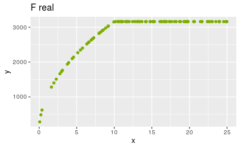

> 2. Generamos datos perturbados con la función **f_real**, agregando rnorm con media cero y desviación estándar 500. El resultado: un normal con media f_real(x) y desviación estándar 500.

```r
genera_datos <- function(n = 100){
  x <- runif(n, 0, 25)
  y <- f_real(x) + rnorm(n, 0, 500)
  tibble(x = x, y = y)
}
calcular_grafica <- function(mod, nombre = ""){
  datos_g <- tibble(x = seq(0, 25, 0.01))
  datos_g <- predict(mod, datos_g) %>%
    bind_cols(datos_g)
  datos_g %>% mutate(nombre = nombre)
}
```

Graficando la forma de la función **f_real** con los datos perturbados generados.

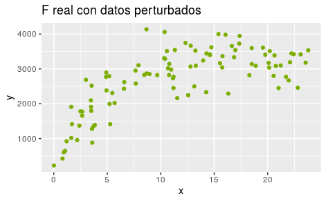

> 3. Generación de métodos que emplearemos para el ajuste de los datos: regresión lineal, polinomio de grado tres y polinomio de grado ocho.

```r
modelo_lineal <- linear_reg() %>%
  set_engine("lm")
modelo_svm <- svm_poly() %>%
  set_engine("kernlab") %>%
  set_mode("regression")
```

Simulamos datos de entrenamiento:

```r
set.seed(8181)
datos <- genera_datos(30)
```

| x | y |
| --- | --- |
| 8.413581 | 3568.1916 |
| 4.373429 | 3298.8953 |
| 22.678043 | 3620.1207 |
| 11.167019 | 3794.2750 |
| 18.582256 | 3070.0667 |
| 6.814984 | 2654.9030 |
| 7.095880 | 2632.1608 |
| 6.527672 | 2508.6736 |
| 10.988194 | 3430.5273 |
| 7.418029 | 2833.8643 |

[output cut: 20 more lines]

> 4. Generamos los objetos de los tres métodos antes mencionados.

```r
# Ajuste
mod_1 <- modelo_lineal %>% fit(y ~ x, datos)
mod_2 <- modelo_svm %>% set_args(cost = 0.1, degree = 3) %>%
  fit(y ~ x, datos)
mod_3 <- modelo_svm %>% set_args(cost = 100, degree = 8) %>%
  fit(y ~ x, datos)
```

Ejemplo de la información guardada en cada uno de los objetos generados anteriormente.

```r
mod_1
```

```
parsnip model object

Fit time:  4ms

Call:
stats::lm(formula = y ~ x, data = data)

Coefficients:
(Intercept)            x
    2247.55        37.85
```

> 5. Generamos datos con cada uno de los métodos antes guardados en objetos y graficamos estos datos en una sola gráfica.

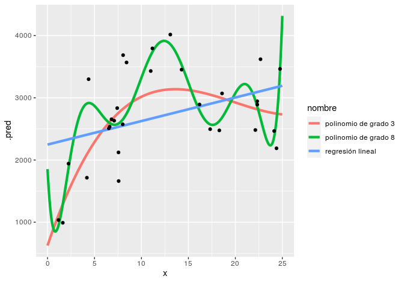

```r
datos_1 <- calcular_grafica(mod_1, "regresión lineal")
datos_2 <- calcular_grafica(mod_2, "polinomio de grado 3")
datos_3 <- calcular_grafica(mod_3, "polinomio de grado 8")

# Unimos las observaciones de los tres modelos en un solo dataframe
datos_g <- bind_rows(datos_1, datos_2, datos_3)

ggplot(datos, aes(x = x)) +
  geom_line(data = datos_g, aes(y = .pred, colour = nombre, group = nombre), size = 1.5) +
    geom_point(aes(y = y))
```

> 6. Repetimos con distintas muestras de entrenamiento. Describe cómo se comporta cada ajuste: sesgo y varianza.

```r
datos_f <- tibble(x = seq(0, 25, 0.01)) %>%
  mutate(.pred = f_real(x)) %>%
  mutate(nombre = "verdadera f")
for (i in 0:6){
  datos_entrena <- genera_datos(100)
  mod_1 <- modelo_lineal %>% fit(y ~ x, datos_entrena)
  mod_2 <- modelo_svm %>% set_args(cost = 0.1, degree = 3) %>%
    fit(y ~ x, datos_entrena)
  mod_3 <- modelo_svm %>% set_args(cost = 100, degree = 8) %>%
    fit(y ~ x, datos_entrena)
  datos_1 <- calcular_grafica(mod_1, "regresión lineal")
  datos_2 <- calcular_grafica(mod_2, "polinomio de grado 3")
  datos_3 <- calcular_grafica(mod_3, "polinomio de grado ocho")
  datos_g <- bind_rows(datos_1, datos_2, datos_3, datos_f)
  Object <- ggplot(datos_entrena, aes(x = x)) +
    geom_line(data = datos_g, aes(y = .pred, colour = nombre, group = nombre), size = 1.5)  +
      geom_point(aes(y = y), size = 1.5) +
    ylim(c(-500, 4500))
  assign(paste0("plot", i), Object)
}
```

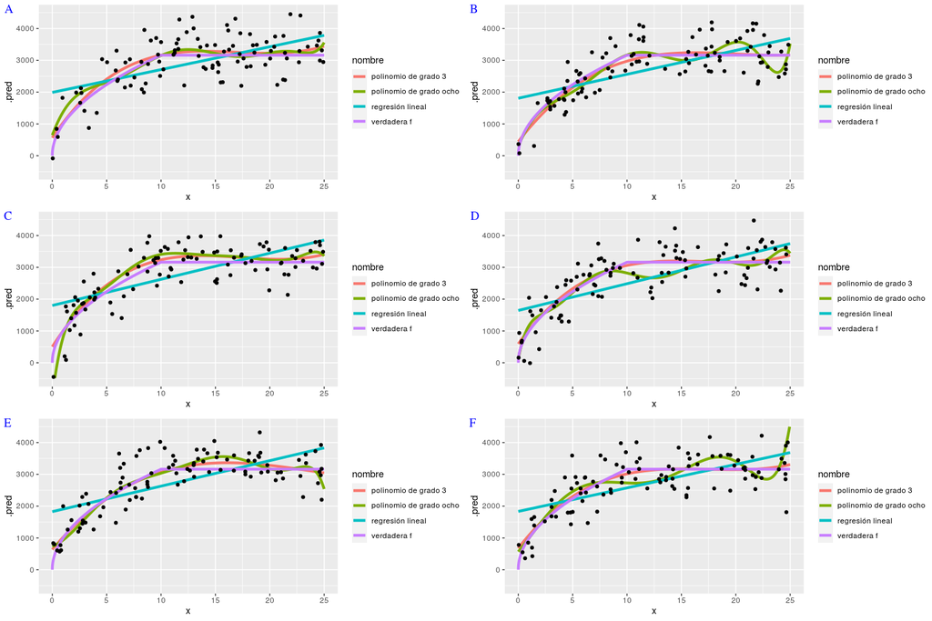

```r
plot_grid(plot1,
          plot2,
          plot3,
          plot4,
          plot5,
          plot6,
          labels = 'AUTO',
          label_fontfamily = "serif",
          label_fontface = "plain",
          label_colour = "blue",
          ncol = 2)
```

**Anotaciones: Observaciones en relación al sesgo y la varianza**